# Maximum Likelihood Estimation

Kushal Kharel

9/11/2022

# Background

- How do we infer sample data to population parameters? One way is to use maximum likelihood estimation method.
- Let us consider a set of observations $y_1, y_2, ..., y_n$, the likelihood function $L$ is the join probability density of obtaining the data that are actually observed.
- It is considered as a function of unknown parameters with the observed data held fixed.
- The maximum likelihood estimators are those values of the parameters for which the data actually observed are most likely. In other words, the values that maximizes the likelihood function.

# Background

- We have i.i.d sample of data, assuming that the data is generated from some parametric density function or the probability mass function which is indexed by parameter $\theta$.
- Then we construct a likelihood function using the assumption that the data are iid which is simply the product of density or pmf evaluated at each sample data points $y_i$.
- We take the log of that function simply because it is computationally easier among other reasons.
- We may have infinite number of possible parameter values, and we want to choose the one that best fits the data. In order to do this, we need to maximize the log likelihood function.

# Generating data

```r
library(dplyr)
library(plotly)
N = 1000
beta = 5
sigma_2 = 5
X = rnorm(N, 0, 5)
Z = rnorm(N, 0, sqrt(sigma_2))
Y = beta*X + Z

DT = data.table::data.table(X, Y, Z)
head(DT)
```

```
##             X          Y          Z
## 1: -5.1031125 -22.608491  2.9070710
## 2:  2.3169936  11.783020  0.1980519
## 3:  3.6623491  19.698005  1.3862593
## 4:  5.4599034  28.181253  0.8817356
## 5: -1.3758629  -8.999021 -2.1197066
## 6:  0.4845064   4.092999  1.6704669
```

# Kernel density Estimation

- a non-parametric method to estimate the probability density function of a random variable based on kernels as weights
- provides a way to see the shape of data

[interactive chart not shown]

# Deriving the log likelihood function

```r
log_like = function(theta, Y, X) {
  X = as.matrix(X)
  Y = as.matrix(Y)
  N = nrow(X)
  beta = theta[1]
  sigma_2 = theta[2]
  e = Y - beta*X
  log_lik = -0.5*N*log(2*pi) - 0.5*N*log(sigma_2) - ((t(e) %*% e)/(2*sigma_2))
  return(-log_lik)
}
```

# Deriving log likelihood values

```r
log_like_plot = function(beta, sigma_2) {
  X = as.matrix(DT$X)
  Y = as.matrix(DT$Y)
  N = nrow(X)
  e = Y - beta*X
  log_lik = -0.5*N*log(2*pi) - 0.5*N*log(sigma_2) - ((t(e) %*% e)/(2*sigma_2))
  return(log_lik)

}
```

# Vectorizing log likelihood values

```r
log_like_plot = Vectorize(log_like_plot)
beta_vals= seq(-10,10,by=1)
sigma_2_vals = seq(1,10,by=1)
log_vals = outer(beta_vals, sigma_2_vals,log_like_plot)
```

# Plotting log likelihood function

[interactive chart not shown]

# Plotting log likelihood function

- The surface in the plot summarizes all the log likelihood values for different beta and sigma values and what we want to do is find the values of beta and sigma squared that hits the highest part of the surface.
- In other words, we want to get different combination of beta and sigma squared values that maximizes the log likelihood function.

# Finding MLE Estimates

```r
library(knitr)

MLE_Estimates = optim(fn = log_like,
                      par = c(1,1),
                      lower = c(-Inf, -Inf),
                      upper = c(Inf, Inf),
                      hessian = TRUE,
                      method = "L-BFGS-B",
                      Y = DT$Y,
                      X = DT$X
                      )
```

# Examining Estimates

```r
MLE_par = MLE_Estimates$par
MLE_SE = sqrt(diag(solve(MLE_Estimates$hessian)))
MLE = data.table::data.table(param = c("beta", "sigma_2"),
                             estimates = MLE_par,
                             sd = MLE_SE)
kable(MLE)
```

| param | estimates | sd |
| --- | --- | --- |
| beta | 4.993428 | 0.0146031 |
| sigma_2 | 5.156092 | 0.2305873 |

# Deriving likelihood values

```r
log_like_plot_beta = function(beta) {
  sigma_2 = MLE_par[2]
  X = as.matrix(DT$X)
  Y = as.matrix(DT$Y)
  N = nrow(X)
  e = Y - beta*X
  log_lik = -0.5*N*log(2*pi) - 0.5*N*log(sigma_2) - ((t(e) %*% e)/(2*sigma_2))
  return(-log_lik)
}
```

# Deriving likelihood values

```r
log_like_plot_sigma2 = function(sigma_2) {
  beta = MLE_par[1]
  X = as.matrix(DT$X)
  Y = as.matrix(DT$Y)
  N = nrow(X)
  e = Y - beta*X
  log_lik = -0.5*N*log(2*pi) - 0.5*N*log(sigma_2) - ((t(e) %*% e)/(2*sigma_2))
  return(log_lik)
}
```

# Vectorizing Estimates

```r
log_like_plot_beta = Vectorize(log_like_plot_beta)
log_like_plot_sigma2 = Vectorize(log_like_plot_sigma2)
```

# Plotting beta

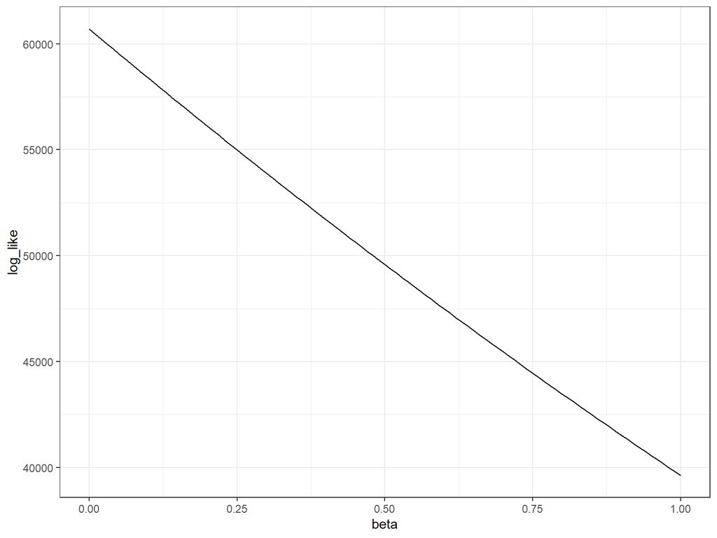

# Plotting Sigma Squared

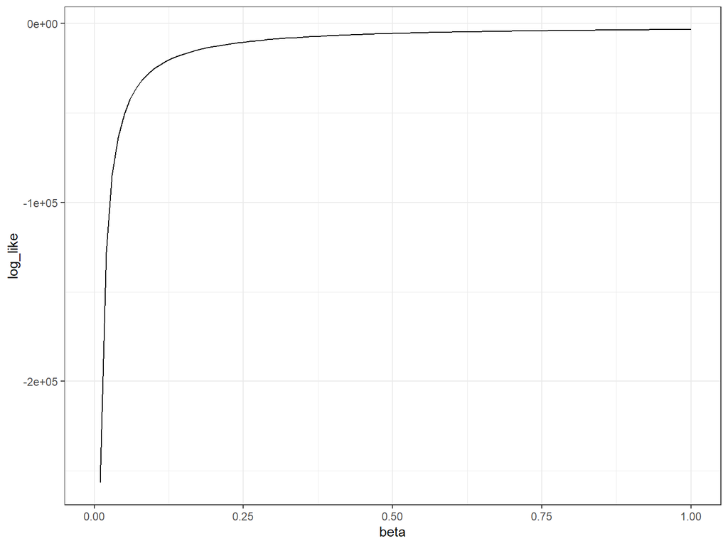

# Binomial Model

- Suppose we have a binomial distribution for N independent bernoulli trials (e.g., coin flips, success or failure etc). There is a probability function that links the number of successes and the probability associated with it.
- The probability function gives the probability of data, given a specific parameter.
- Let’s see the barplot for probability function where N = 25 trials and fixed parameter theta = 0.5. In each of these 25 trials, the probability of landing heads is 50%.

# Density Plot

[interactive chart not shown]

# Plot Summary

- The plot represents the probability of getting each possible number of heads in 25 outcomes.We can see that most of the occurences are between 12 and 15.
- The most probable outcome is 12 and 13.
- It tells the probability of each discrete outcome.

# Binomial Model in action

- There is a likelihood function that gives the likelihood of a range of parameters, given a specific data point.
- Now, our input is parameters instead of data, this is called likelihood function.

# Binomial Example

- Suppose we observe ten successes in 25 trials. Here we are not asking about the probability of 10 successes but instead asking what is the parameter that would have given us 10 successes.
- Let us see the plot explained above. Suppose that in the sequence of 25 coin flips, we observe 10 successes(heads).
- What is the maximum likelihood estimate for theta? Assume binomial model.

# Defining likelihood function

```r
negative_log_likelihood_binom = function(data, par) {
  return(-log(dbinom(data, size = 25, prob = par)))
}
```

# Finding parameters that maximizes the likelihood function

```r
optim(par = 0.5, fn = negative_log_likelihood_binom, data = 10)
```

```
## $par
## [1] 0.4
##
## $value
## [1] 1.82537
##
## $counts
## function gradient
##       28       NA
##
## $convergence
## [1] 0
##
## $message
## NULL
```

```r
theta = seq(from = 0, to = 1, by = 0.01)
```

# Plotting likelihood

[interactive chart not shown]

# Summary

- The plot is telling us that the likelihood of observing 10 successes over the range of possible values of theta. We can see from the plot, as theta approaches 0.4, the likelihood goes up.
- We can ask the question that what value of theta is most likely, given the data we observed?
- We can see that our optimized parameter MLE = par = 0.4.